# Comparing waveform lidar and discrete lidar for vegetation density estimation

Created by:

```
* Amanda Schwantes
* Leticia Lee
* Geraldine Klarenberg
```

Jupy 14, 2018 during the NEON Data Institute

Import Libraries

```python
import numpy as np
import time
from matplotlib import pyplot as plt
import NEON_AOP_waveform_tools
import csv
import pandas as pd
from mpl_toolkits.mplot3d import Axes3D
from IPython.display import Image
```

NEON_AOP_waveform_tools is a python script, written by Tristen, which will be available on the NEON github site.

To unzip plz files you can use the pulsewaves tool, which is available for download [here](https://rapidlasso.com/pulsewaves/)

To unzip we did this step in command line, but here's the syntax:

`cd C:\pulsewavesDLL\pulsewavesDLL`

`pulse2pulse -i ".\RSDI-2018\capstone\data\Pulsewaves\NEON_D03_OSBS_DP1_L014-1_2017092713_translate.plz" -opls`

Then, load file

```python
PlsFile = r"C:\Users\Amanda Schwantes\Documents\RSDI-2018\capstone\data\PR\NEON_D04_GUIL_DP1_L009-1_2018052110_translate_1.pls"

#PlsFile = r"C:\Users\Amanda Schwantes\Documents\RSDI-2018\data\NEON-Fri\WaveformLidar\2015032618_Q780_150326_194954_1_originalpoints.pls"
```

To loop through all the pulses within the file, we need to determine the number of pulses.

```python
#Determine number of pulses
fin_pls_file = open(PlsFile,"rb")
fin_pls_file.seek(184,0)
number_of_pulses = np.fromfile(fin_pls_file,np.int64,1)
number_of_pulses = number_of_pulses[0]
print(number_of_pulses)
```

```
7692085
```

Here we are looping through multiple pulses within the file. For each pulse, we are running a Gaussian decomposition, using the Levenberg–Marquardt algorithm. For each detected peak, we are finding the full width half max point (e.g. the leading edge).

```python
GaussianCalcTime = time.clock()
tot_peaks_old=0

pulses = np.arange(1,10)

xyz_coords = []
xyz_coords = np.zeros((10000*10,5)) # make a lot of rows... (max 7 peaks per pulse)

for pulse in pulses:

    #num_peaks_in = []

    pulse=[pulse]
    # Read in pulse number info
    # 1) coordinate info
    # 2) received wave
    # 3) outgoing wave
    coord_info, wave_in, wave_out = NEON_AOP_waveform_tools.waveform_read(pulse,PlsFile)
    # print coordinates
    #print(coord_info) # first number is GPS time, next 3 describe the direction of the (3d coordinates),
    # last three number are the actual coordinates the start of the pulse (x,y,z)

    initial_params_out = NEON_AOP_waveform_tools.get_params(wave_out[0])
    initial_params_in = NEON_AOP_waveform_tools.get_params(wave_in[0])

    if (initial_params_in.sum() > 0):

        num_peaks_in = np.array(initial_params_in[0,-1]) # number of peaks is saved in this location

        #WFtime = np.arange(1,244) # set up time (ns bins)

        #fit_wave_final = NEON_AOP_waveform_tools.get_fit_wave(initial_params_in, 244, num_peaks_in)

        temp_out_params = NEON_AOP_waveform_tools.get_gaussian_params(initial_params_out,wave_out[0],10,20,0)[0]

        temp_in_params = NEON_AOP_waveform_tools.get_gaussian_params(initial_params_in,wave_in[0],10,20,0)[0]

        fit_wave_final = NEON_AOP_waveform_tools.get_fit_wave(temp_in_params,244,num_peaks_in)

        FWHM = (2.355*(initial_params_in[0,2:int(num_peaks_in*3):3]/2**0.5))/2 # full width half max. Grab 3rd, 6th, 9th parameters

        #trig_loc = initial_params_in[0,1:int(num_peaks_in*3):3] - FWHM
        #trig_loc  = np.reshape(trig_loc,(int(num_peaks_in),1))

        # normalize trigger locations by the location of the outgoing pulse
        # trig_loc = initial_params_in[0,1:int(num_peaks_in*3):3]-FWHM-initial_params_out[0,1]
        # trig_loc = np.reshape(trig_loc,(int(num_peaks_in),1))

        trig_loc = temp_in_params[0,1:int(num_peaks_in*3):3]-FWHM-temp_out_params[0,1]
        trig_loc = np.reshape(trig_loc,(int(num_peaks_in),1))

        pulse_coords = (np.matlib.repmat(trig_loc[:,0],3,1)).transpose()*coord_info[:,1:4]+coord_info[:,4:7]
        #print(pulse_coords)

        tot_peaks_new = tot_peaks_old + num_peaks_in
        #print(tot_peaks_new)

        for k in np.arange(int(tot_peaks_old), int(tot_peaks_new)):
            #print(k)
            xyz_coords[k,0:3] = pulse_coords[:,0:3][k-int(tot_peaks_old)]
            xyz_coords[k,4] = k-int(tot_peaks_old)
            xyz_coords[k,3] = pulse[0]
            #print(pulse[0])

        tot_peaks_old = tot_peaks_new
        #print(type(pulse[0]))

print('Total time is {}'.format(time.clock()-GaussianCalcTime))

xyz_coordsDF = pd.DataFrame(data=xyz_coords,
                columns=['x','y','z','pulse','return'])  # 1st row as the column names

xyz_coordsDF.to_csv('../output/waveformXYZ_0714_2018.csv', sep=',')
```

```
1
Total time is 3.98532684057971
```

```
UTM x min: 733720.2060559744and max: 734414.4858104966
UTM y min: 2011741.7231886375and max: 2011846.2517685469
```

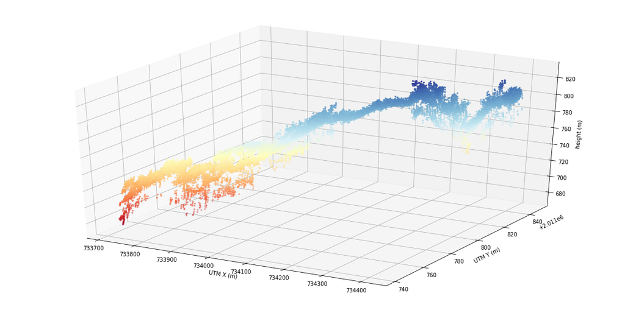

```python
xyz_coordsDF = pd.read_csv('../output/waveformXYZ_0713_2018c.csv', sep=',')

indexNZ = xyz_coordsDF["x"].nonzero()[0][-1]

#this removes empty zero rows.
xyz_coords = np.array(xyz_coordsDF)

xyz_coords2 = xyz_coords[0:indexNZ,:]

#This one removes birds (errors)
indexLow = np.where(xyz_coords2[:,3] < 1200)

xyz_coords3 = xyz_coords2[indexLow,:][0]

fig = plt.figure(figsize = (20,10))
ax = fig.add_subplot(111, projection='3d')

cm = plt.cm.get_cmap('RdYlBu')

sc = ax.scatter(xyz_coords3[:,1], xyz_coords3[:,2], xyz_coords3[:,3], c=xyz_coords3[:,3], marker='.', cmap = cm, s = 20)

ax.set_xlabel('UTM X (m)')
ax.set_ylabel('UTM Y (m)')
ax.set_zlabel('height (m)')

plt.savefig('../output/WaveformProfile.png')

#this prints the UTMS so we can find them later
print('UTM x min: ' + str(np.amin(xyz_coords2[:,1])) + 'and max: ' + str(np.amax(xyz_coords2[:,1])))
print('UTM y min: ' + str(np.amin(xyz_coords2[:,2])) + 'and max: ' + str(np.amax(xyz_coords2[:,2])))
```

We can then examine the profile for the discrete Lidar

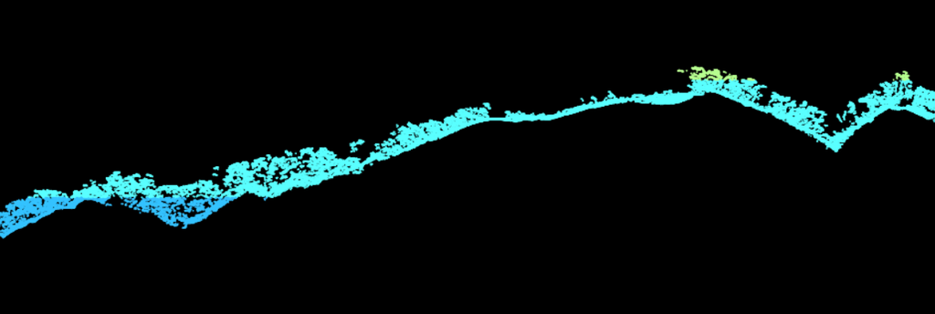

```python
Image(r"C:\Users\Amanda Schwantes\Documents\RSDI-2018\capstone\output\discrete_profileTotal.png")
```

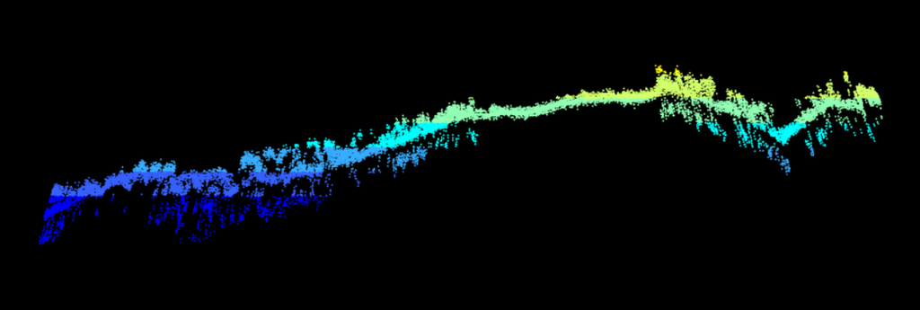

```python
Image(r"C:\Users\Amanda Schwantes\Documents\RSDI-2018\capstone\output\waveform_profileT.png")
```

To process the discrete lidar we first unzipped the laz files using lastools.

We ran this in command line, but the syntax is as follows: Replace the "." with your directory.

navigate to Lastools `cd "C:\LAStools\LAStools\bin"`

`laszip -i ".\Documents\RSDI-2018\capstone\data\Discrete\zipped\*.laz" -odir ".\Documents\RSDI-2018\capstone\data\Discrete\LasFiles"`

To create a list of las files to process:  
`cd ".\Documents\RSDI-2018\capstone\data\Discrete\LasFiles`  
`DIR /b /s *.las | findstr .las$ > lidar_dir.txt`

To create a DTM with just the classified ground points navigate to the fusion folder  
`cd "C:\FUSION"`

```
TinSurfaceCreate /class:2 ".\Documents\RSDI-2018\capstone\data\Discrete\DTM\PR_DTM_2.dtm" 5 m m 1 19 2 2 ".\Documents\RSDI-2018\capstone\data\Discrete\LasFiles\lidar_dirSub.txt"
DTM2ASCII /raster ".\Documents\RSDI-2018\capstone\data\Discrete\DTM\PR_DTM_2.dtm"
```

To Create a vegetation density layer (e.g., first returns over 1-m divided by all first returns)

```
cover /class:~7 ".\Documents\RSDI-2018\capstone\data\Discrete\DTM\PR_DTM_2.dtm" ".\Documents\RSDI-2018\capstone\data\Discrete\DTM\PR_cover_2.dtm" 1 5 M M 1 19 2 2 ".\Documents\RSDI-2018\capstone\data\Discrete\LasFiles\lidar_dirSub.txt"
DTM2ASCII /raster ".\Documents\RSDI-2018\capstone\data\Discrete\DTM\PR_cover_2.dtm"
```